# MachineLearningAssignment

CH

16 März 2017

# Load data

The datasets are downloaded if they do not already exist in the current directory. We consider “#DIV/0!” as NA.

```r
library(caret)
library(dplyr)
```

```r
library(ggplot2)
library(tidyr)

if (!file.exists("pml-training.csv"))
  download.file("https://d396qusza40orc.cloudfront.net/predmachlearn/pml-training.csv",
                destfile = "pml-training.csv")
if (!file.exists("pml-testing.csv"))
  download.file("https://d396qusza40orc.cloudfront.net/predmachlearn/pml-testing.csv",
                destfile = "pml-testing.csv")

training <- read.csv("pml-training.csv",
                     na.strings = c("NA", "#DIV/0!"))
testing <- read.csv("pml-testing.csv",
                     na.strings = c("NA", "#DIV/0!"))
```

# Preprocessing

The original dataset seems to contain time series data as well as summary data of that describe the data during a certain time window. These summary variables have values only in the rows that contain the new_window value “yes”, and therefore, these variables contain mostly NAs and are excluded from the model.

```r
training <-
  training %>%
  select(-(1:7)) %>%
  select(-starts_with("var"),
         -starts_with("avg"),
         -starts_with("min"),
         -starts_with("max"),
         -starts_with("skewness"),
         -starts_with("kurtosis"),
         -starts_with("amplitude"),
         -starts_with("stddev"))


trainingClasse <- training$classe

training <- training %>% select(-matches("classe"))

testing <-
  testing %>%
  select(-(1:7)) %>%
    select(-starts_with("var"),
         -starts_with("avg"),
         -starts_with("min"),
         -starts_with("max"),
         -starts_with("skewness"),
         -starts_with("kurtosis"),
         -starts_with("amplitude"),
         -starts_with("stddev"))

testingID <- testing$problem_id

testing <- testing %>% select(-matches("problem_id"))

print(dim(training))
```

```
## [1] 19622    52
```

```r
print(dim(testing))
```

```
## [1] 20 52
```

Because some variables seem quite skewed, let’s center and scale the variables, and do a BoxCox transformation. A density plot allows screening for the result of the preprocessing procedure.

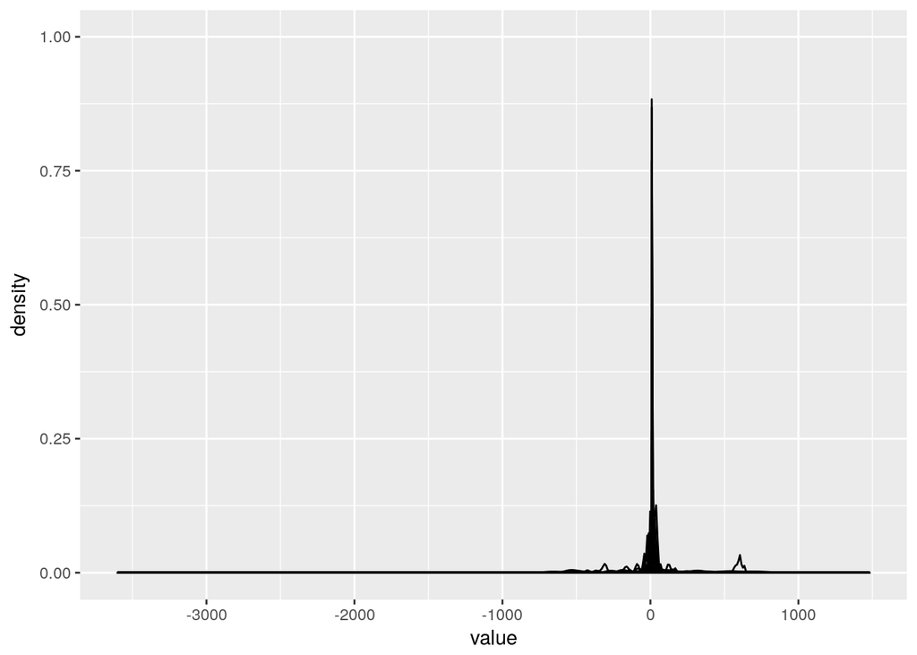

```r
ggplot(training %>% gather(variable, value),
       aes(group = variable, x = value)) + geom_density() +
  scale_y_continuous(limits = c(0, 1))
```

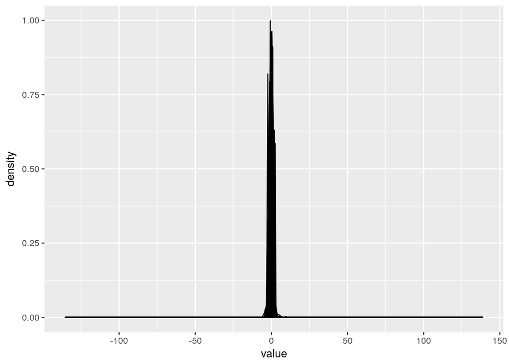

```r
preProp <- preProcess(training, method = c("center", "scale", "BoxCox"))

trainingPreProp <- predict(preProp, training)

testingPreProp <- predict(preProp, testing)

ggplot(trainingPreProp %>% gather(variable, value),
       aes(group = variable, x = value)) + geom_density() +
    scale_y_continuous(limits = c(0, 1))
```

# Model selection using k-fold crossvalidation to estimate out-of-sample error.

I have started using 5-fold crossvalidation for the whole dataset. However, this takes a really long time. Therefore, I have decided to use subsets of the whole dataset to select a model and then use the whole dataset only for the final model.

```r
trainingFinal <- data.frame(classe = trainingClasse, trainingPreProp)

sset <- createFolds(trainingFinal$classe, 10, list = F)
trainingNew <- trainingFinal[sset == 1,]
```

## Recursive Partitioning

```r
folds <- createFolds(trainingNew$classe, 5, list = F)

acc <- c()
for (i in 1:max(folds)) {
  i <- 1
  model <-  train(classe ~ ., method = "rpart",
                  data = trainingNew[folds != i, ])
  acc <- c(acc,
           confusionMatrix(predict(model, trainingNew[folds == i, -1]),
                           trainingNew[folds == i, 1])$overall[1]
  )

}
print(acc)
```

```
##  Accuracy  Accuracy  Accuracy  Accuracy  Accuracy
## 0.5038168 0.5038168 0.5038168 0.5038168 0.5038168
```

The estimated out-of-sample accuracy for the first model is 0.5038168.

## Random Forest

To speed up model selection, I have decided to reduce k to 3 for random forest and treebag.

```r
folds <- createFolds(trainingNew$classe, 3, list = F)

acc <- c()
for (i in 1:max(folds)) {
  i <- 1
  model <-  train(classe ~ ., method = "rf",
                  data = trainingNew[folds != i, ])
  acc <- c(acc,
           confusionMatrix(predict(model, trainingNew[folds == i, -1]),
                           trainingNew[folds == i, 1])$overall[1]
  )

}
print(acc)
```

```
##  Accuracy  Accuracy  Accuracy
## 0.9129771 0.9160305 0.9145038
```

The estimated out-of-sample accuracy for the first model is 0.9145038.

## Treebag

```r
folds <- createFolds(trainingNew$classe, 3, list = F)

acc <- c()
for (i in 1:max(folds)) {
  i <- 1
  model <-  train(classe ~ ., method = "treebag",
                  data = trainingNew[folds != i, ])
  acc <- c(acc,
           confusionMatrix(predict(model, trainingNew[folds == i, -1]),
                           trainingNew[folds == i, 1])$overall[1]
  )

}
print(acc)
```

```
##  Accuracy  Accuracy  Accuracy
## 0.8975535 0.9082569 0.9174312
```

The estimated out-of-sample accuracy for the first model is 0.9077472.

# Prediction of the test cases

```r
finModel <-  train(classe ~ ., method = "rf",
                   data = trainingFinal)

print(data.frame(problem_id = testingID, predict(model, testingPreProp)))
```

```
##    problem_id predict.model..testingPreProp.
## 1           1                              B
## 2           2                              A
## 3           3                              A
## 4           4                              A
## 5           5                              A
## 6           6                              E
## 7           7                              D
## 8           8                              D
## 9           9                              A
## 10         10                              A
## 11         11                              C
## 12         12                              C
## 13         13                              B
## 14         14                              A
## 15         15                              E
## 16         16                              E
## 17         17                              A
## 18         18                              D
## 19         19                              B
## 20         20                              B
```